# Visualização de Dados

11 de Abril de 2018

**Justificativa**

- A cada 2 anos dobramos a quantidade de informação produzida.
- Era do BIG DATA: volume, velocidade e variedade.
- Processamos melhor a informação visual.
- A análise exploratória é parte fundamental do processo de análise.
- Gráficos ruins/inadequados estão por toda parte.
- Gráficos adequados podem complementar ou até descrever melhor resultados das análises estatísticas.

**Objetivo**

- Definir visualização de dados para análise exploratória e explanatória.
- Apresentar gráficos para compreensão de variáveis categóricas, contínuas e suas relações.
- Apresentar gráficos estáticos e reativos.
- Dar recomendações sobre boas práticas na visualização de dados.
- Mostrar recursos na linguagem R para visualização de dados.

> **Uma imagem** vale mais que **mil palavras**.

> – Provérbio inglês

## Visualização de dados

## O que são os gráficos?

- São um recurso para visualizar informação dos dados que são representadas de forma ilustrativa, pictorial ou geométrica.
- Mapeiam quantidades em atributos geométricos (posição, comprimento, área, cor, símbolo, linha, curva, polígono) geralmente utilizando um sistema coordenado como referência e elementos estéticos.

## Para que eles servem?

Gráficos são usados para

- Explorar a informação contida nos dados.
- Compreender os dados, as variáveis observadas e o fenômeno correspondente de forma rápida.
- Apresentar a informação de/em muitas variáveis em pouco espaço.
- Reconhecer organização, estrutura, padrões e relações entre variáveis.
- Detectar problemas: incompleto, incorreto, inconsistente e impreciso.
- Avaliar as suposições e qualidade de um modelo estatístico.
- Comunicar resultados de análises estatísticas.

## História e futuro

- O uso de mapas é bem antigo: cartografia.
- Primeiros gráficos de dados são do século 17.
- Confecção analógica de gráficos: limitação de tempo e quantidade.
- Impulsão em 1970 com os computadores: confecção digital.
- Era do BIG DATA: compreender dados de fenômenos complexos.
  - Grande volume: padrões mais evidentes.
  - Grande variedade: contínuos, categóricos, geográficos, cronológicos, circulares, composicionais, textuais.
  - Grande velocidade: tomar decisões rapidamente.
- [O top 10 das tendências para inteligência de mercado](https://www.tableau.com/reports/business-intelligence-trends).
  1. Inteligência artificial.
  2. **Impacto das artes liberais: visualização, design, storytelling.**
  3. Processamento de linguagem natural.

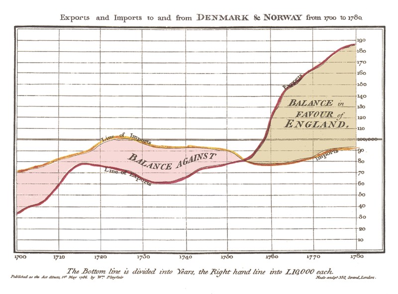

Figura 1: Balança comercial da Inglaterra no período de 1700 a 1780 representada em um gráfico de linhas por William Playfair em 1786. [FONTE](https://en.wikipedia.org/wiki/File:Playfair_TimeSeries-2.png).

[figure not shown]

Figura 1: Mortes por cólera em Londres em 1854 sinalizadas no mapa por John Snow para detecção da fonte de contaminação. [FONTE](https://en.wikipedia.org/wiki/File:Snow-cholera-map-1.jpg).

[figure not shown]

Figura 2: Mapa de intensidade sobre as localização das mortes por cólera. [FONTE](https://medium.com/public-health/john-snow-early-big-data-science-d62b4dacd71b).

## Tipos variáveis

Com relação **tipo de valor** das variáveis:

- Variáveis **métricas** ou quantitativas.
  - **Discretas**: valores contáveis em intervalo finito.
    - Número de irmãos.
    - Número de sinistros/acidentes.
  - **Contínuas**: valores incontáveis em intervalo finito.
    - Altura.
    - Distância percorrida até o trabalho.
- Variáveis **categóricas** ou qualitativas.
  - **Nominais**: não pussem ordenação natural.
    - Possuir animal de estimação.
    - Estado em que nasceu.
  - **Ordinais**: possuem ordenação natural.
    - Nível de escolaridade.
    - Graduação no karatê.

## Limitação do suporte

Quanto a limitação do suporte, as variáveis podem ter:

- Suporte aberto: \(-\infty < X < +\infty\).
- Suporte fechado: \(X \in [0, 1)\).
- Suporte semi-aberto: \(X \in [0, \infty)\).
- Suporte circular: \(X \in [0, 2\pi)\).

## Quantidade de variáveis

Com relação a **quantidade de variáveis** representadas:

- Univariados: representa apenas uma variável.
- Bivariados: representa duas variáveis.
- Multivariados: representa 3 ou mais variáveis.

## Tipos especiais de variáveis

- Cronológicas: instantes, períodos, durações.
  - Datas: ano, mês e dia.
  - Tempo: hora, minuto e segundo.
  - Data-tempo: a junção das duas.
  - Complicações: irregularidade, fusos, cíclio, censuras.
  - Ex: análise de sobreviência.
- Geográfico: coordenadas, rotas, polígonos.
  - Dados na superfície da Terra.
  - Complicações: projeções cartográficas, polígonos irregulares.
  - EX: geoestatística, processo pontual.
- Espaço-temporal: junção do geográfico com cronológico.
- Composicional: teores que somam um valor fixo.
  - Complicação: a restrição de soma.
  - Ex: modelos de mistura de componentes.

## Emprego de gráficos

| Análise exploratória | Análise explanatória |
| --- | --- |
| **Explorar** os dados, ganhar intimidade | **Comunicar** resultados das análises |
| Geram **perguntas** | Geram **respostas** |
| Permitem **criar e refinar** de hipóteses | Permitem **confirmar** hipóteses |
| É para consumo do **cientista** | É para consumo de **interessados/apoiadores** |
| É um processo exaustivo: **muitos gráficos** são criados | Apenas os **gráficos principais** são exibidos |
| Muitos gráficos: conteúdo redundante e **conto prolixo** | Gráficos essenciais: enxutos, claros e **conto conciso** |
| Sem preocupação com design e acabamento | Design e acabamento são importantíssimos |
| Selecionar variáveis, compreender tamanho de efeito, eliminar outliers | Orientar o desenvolvimento das pesquisas, novas hipóteses |
| Auxiliar a especificar o modelo, avaliar suposições, corrigir problemas | Estimular a compreensão e ação: tomada de decisão |
| Geralmente estáticos | Podem ser reativos |

## Prática no R

## Conjuntos de dados

- http://leg.ufpr.br/~walmes/data/coberturas-venda-cwb-26Jan2018.txt;
- http://leg.ufpr.br/~walmes/data/ap_venda7bairros_cwb_210314.txt;
- http://leg.ufpr.br/~walmes/data/carros_venda_webmotors_270314.txt;
- http://leg.ufpr.br/~walmes/data/triathlon.txt;
- http://leg.ufpr.br/~walmes/data/euro_football_players.txt;
- http://leg.ufpr.br/~walmes/data/saosilvestre_fwf.txt;
- http://leg.ufpr.br/~walmes/data/aval_carros_nota.txt;

## Mais opções de gráficos

## Stacked dot plot

- Uma alternativa ao histograma quando a variável é discreta.

[figure not shown]

## Violin plot

- Uma representação que mistura o boxplot com o density para acomodar várias densidades conforme muda os níveis de um fator.
- [`ggplot::geom_violin()`](http://www.sthda.com/english/wiki/ggplot2-violin-plot-quick-start-guide-r-software-and-data-visualization).

[figure not shown]

Figura 1: Exemplo de um gráfico de violino. [FONTE](http://www.storybench.org/getting-started-data-visualization-r-using-ggplot2/).

## Beeswarm plot

- Uma alternativa para representar a distribuição de dados discretos.
- Pacote R [`beeswarm`](http://www.cbs.dtu.dk/~eklund/beeswarm/).

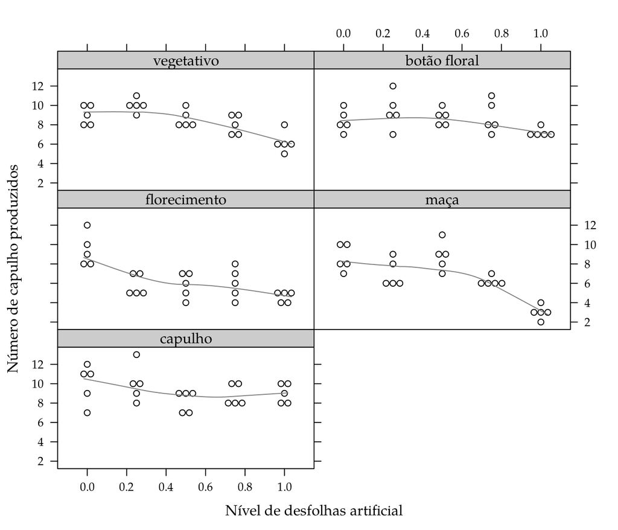

Figura 1: Número de capulhos produzídos em função no nível de desfolha e fase de desenvolvimento de plantas de algodão. [FONTE](http://leg.ufpr.br/~walmes/pacotes/MRDCr-vignettes/v06_gamma_count.html).

## Joyplot

- Alternativa ao *violin plot* para representar a distribuição de uma variável conforme os nível de outra.

[figure not shown]

## Circular plot

- Para representar a distribuição de dados direcionais ou cíclicos.

[figure not shown]

## Gráfico de contornos ou níveis

[figure not shown]

## Superfícies

[figure not shown]

## Mapas de calor

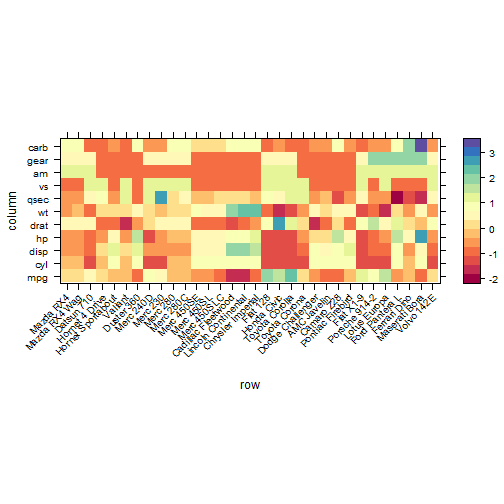

## Calendário de calor

[figure not shown]

## Network ou rede de relacionamentos

[figure not shown]

## Circles plot

- Utilizado para representar movimentos migratórios, ligações gênicas, transações bancárias, etc.

[figure not shown]

## Word cloud

[figure not shown]

## Correlograma

[figure not shown]

## Tree map

- Representa no plano as divisões de uma árvore.

[figure not shown]

## Quantil quantil plot

[figure not shown]

## Scatterplot matrix

[figure not shown]

## Dendrograma

[figure not shown]

## Biplot

[figure not shown]

## Chernoff faces

[figure not shown]

```r
opts_chunk$set(echo = FALSE)
```

## Não fazer ou evitar

## Gráficos de setores

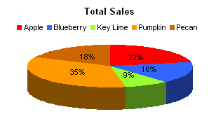

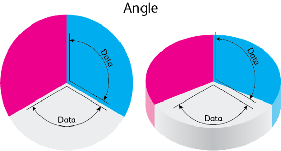

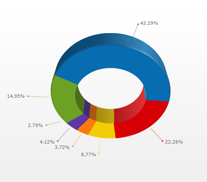

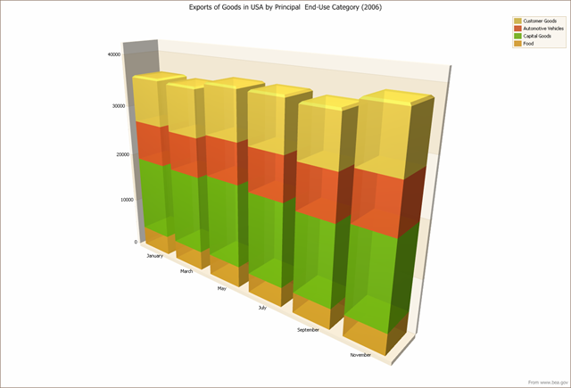

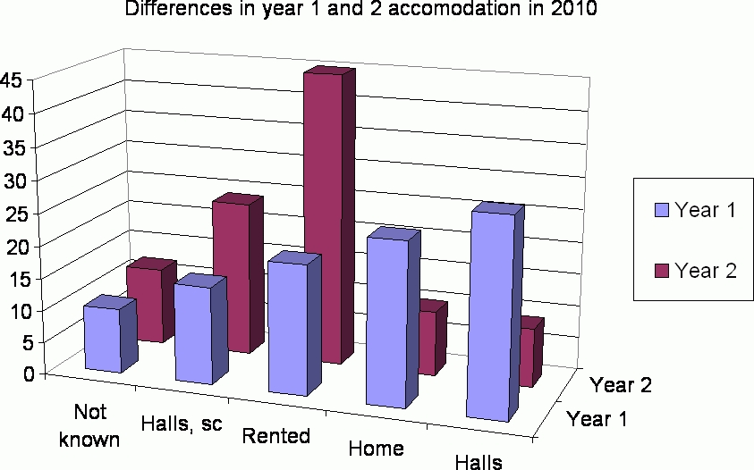

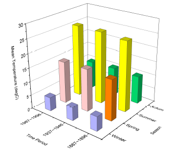

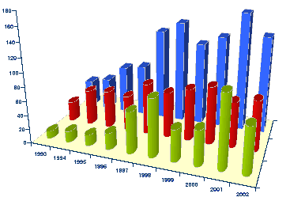

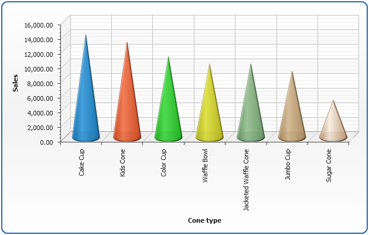

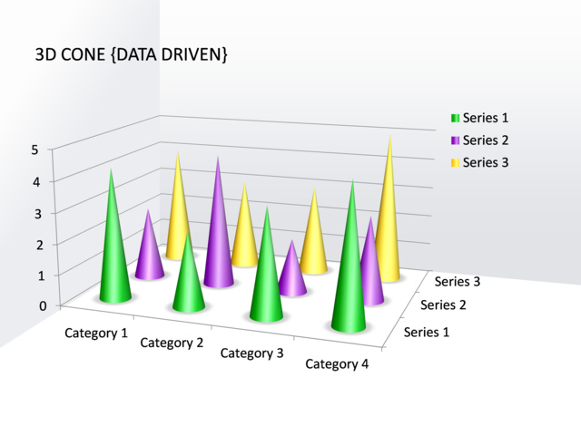

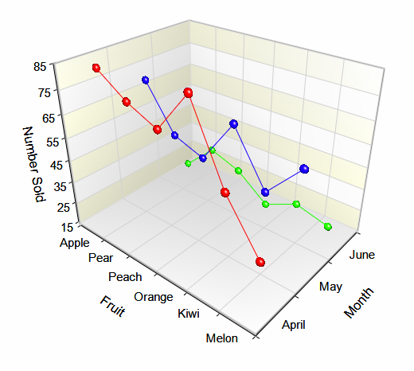

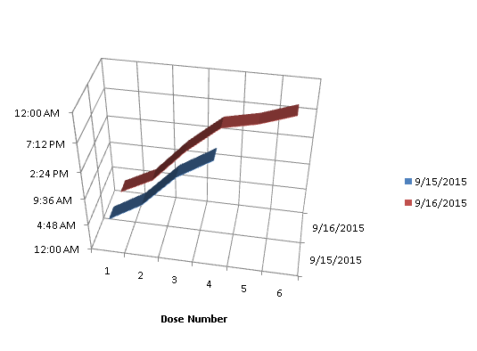

## Considerações finais

- **Estão todos vivos?**
- Gráficos são fundamentais no processo de análise de dados.
- Existe uma variedade grande de opções disponíveis.
- O bom uso de gráficos vem com o tempo.
- Atente-se para que ele seja claro, enxuto e conciso.
- NÃO USE GRÁFICOS EM 3D.
- Invista tempo para aprender um bom software para confecção de gráficos.

Obrigado!